# STAT 1910 Project Data Proposal

Last updated on 2022-10-30

```r
# Load all packages here:
library(readr)
library(dplyr)
library(ggplot2)
library(janitor)

# Set seed value of random number generator to get "replicable" random numbers.
# The choice of seed value of 76 was an arbitrary one on my part.
set.seed(76)
```

# Big-picture

## Research question

How does GPA and region of the university effect salary for engineers?

## Description of data

Extensive data on engineering graduates from diffrent states of India containing both quantitative and qualitative data measuring various factors which may play a role on their post-graduate salary.The dataset was attained from https://www.kaggle.com/datasets/manishkc06/engineering-graduate-salary-prediction - dataset made publicly available from https://www.hbs.edu/faculty/Pages/item.aspx?num=50096

## Load data into R

*Include the code to load your data here. If your data is not confidential nor is it private in nature, consider publishing it as a `.csv` file on Google Sheets as in the code chunk below; instructions on how to do this are in Steps 1-6 [here](https://twitter.com/rudeboybert/status/1055821846539591680). If the data shouldn’t be published online, then please submit the spreadsheet file on Moodle.*

```r
df <- read_csv("https://docs.google.com/spreadsheets/d/e/2PACX-1vQ9x2onmfCFbaBW0DCiTbhpac5m7SpyP3RgcbGnFm5B3twBW8CUzZEqqVtxObI2xEGKo9HZ4M5j7oyS/pub?gid=776035216&single=true&output=csv")
```

## Clean variable names

*Piping your data frame into the `clean_names()` function from the `janitor` package will clean your variable names, making them easier to work with.*

```r
df <- df %>%
    clean_names()
```

## Explore your data

*Be sure to explore your data. Note that `eval=FALSE` is set so that R Markdown doesn’t “evaluate” this code chunk, i.e. it will ignore it in the ultimate `.html` report. You should run this code on your own, but not in the ultimate `.html` report.*

```r
glimpse(df)

df %>%
    nrow()

df %>%
    ls()

glimpse(df)
```

# Variables

## Identification variable

*What is your identification (ID) variable (if you have one)?* The identification variable is id

## Outcome variable

*What is your outcome variable $y$? What are its units of measurement?* The outcome variable is the post-graduate salary in Indian Rupees (INR).

## Numerical explantory variable

*What is your numeric explanatory variable? What are its units of measurement?* The numeric explanatory variable is college_gpa, representing the grade of the student.

## Categorical explantory variable

*What is your categorical explanatory variable? Does it have between 3 and 5 levels. Please list the different levels.* college_state is the categorical variable, representing the region the schools the levels are [North, South, West, East, Central].

# Rows/observations

## Observational units

*What is the observational unit of your data? In other words, what does each row in your data represent?* Each observational unit represents data for a graduated engineering student.

## Sample size

*How many rows/cases are in the data i.e. what is the sample size? Is the sample size at least 50?* There is 2998 rows in this dataset.

# Preview of data

## Pare down variables

*`select()` the following variables **in this order** and drop all others. Eliminating all unnecessary variables will making visually exploring the raw values less taxing mentally, as we’ll have less data to look at.*

1. *The identification variable*
2. *The outcome variable $y$*
3. *The numerical explanatory variable*
4. *The categorical explanatory variable*
5. *Optional: any other variable you find interesting*

id, salary, college_gpa, college_state, and gender were selected out of the dataset, also college_state was changed from a by-state organization to grouped by region. Some variables were renamed for clarity and simplification.

```r
# Compacting states into regions of North, South, West, East, Central
df$college_state[df$college_state == 'Chhattisgarh' | df$college_state == 'Madhya Pradesh'] <- 'Centeral'

df$college_state[df$college_state == 'Delhi' | df$college_state == 'Haryana' | df$college_state == 'Jammu and Kashmir' | df$college_state == 'Himachal Pradesh' | df$college_state == 'Uttar Pradesh' | df$college_state == 'Punjab' | df$college_state == 'Uttarakhand' | df$college_state == 'Rajasthan' | df$college_state == 'Ladakh' | df$college_state == 'Chandigarh' | df$college_state == 'Union Territory' | df$college_state == 'Meghalaya'] <- 'North'

df$college_state[df$college_state == 'Tamil Nadu' | df$college_state == 'Kerala' | df$college_state == 'Karnataka' | df$college_state == 'Andhra Pradesh' | df$college_state == 'Telangana' | df$college_state == 'Puducherry'] <- 'South'

df$college_state[df$college_state == 'Maharashtra' | df$college_state == 'Goa' | df$college_state == 'Gujarat' | df$college_state == 'Assam' | df$college_state == 'Drissa' | df$college_state == 'Sikkim' | df$college_state == 'Goa'] <- 'West'

df$college_state[df$college_state == 'Bihar' | df$college_state == 'Jharkhand' | df$college_state == 'Odisha' | df$college_state == 'Orissa' | df$college_state == 'West Bengal'] <- 'East'

df <- rename(df, gpa = college_gpa)
df <- rename(df, region = college_state)

df <- df %>%
    select(id, salary, gpa, region, gender)

glimpse(df)
```

```
## Rows: 2,998
## Columns: 5
## $ id     <dbl> 604399, 988334, 301647, 582313, 339001, 609356, 1081649, 610842…
## $ salary <dbl> 445000, 110000, 255000, 420000, 200000, 440000, 150000, 105000,…
## $ gpa    <dbl> 73.82, 65.00, 61.94, 80.40, 64.30, 99.93, 68.00, 71.00, 73.15, …
## $ region <chr> "North", "North", "West", "North", "South", "North", "East", "S…
## $ gender <chr> "f", "m", "m", "m", "f", "f", "f", "f", "m", "f", "m", "m", "f"…
```

## Preview data

*Display a random sample of 5 rows of your data frame by piping it into the `sample_n(5)` function from the `dplyr` package . You’ll get the same 5 rows everytime you knit this document and hence replicable results because we set the seed value of the random number generator in the first code chunk above.*

```r
df %>%
    sample_n(5)
```

| id | salary | gpa | region | gender |
| --- | --- | --- | --- | --- |
| 965196 | 305000 | 75.00 | South | f |
| 223212 | 650000 | 67.40 | East | m |
| 1119237 | 400000 | 77.00 | East | m |
| 1274331 | 180000 | 73.12 | North | m |
| 198026 | 340000 | 70.12 | North | m |

# PART 2

# Exploratory data analysis

*Let’s do an little exploratory data analysis.*

## Inspect for missing values

*Address missing values.* There is no null values in this dataset, however GPAs on a diffrent measurment system from 1-10 were omitted

```r
df$gpa[df$gpa < 50] <- NA
colSums(is.na(df))
```

```
##     id salary    gpa region gender
##      0      0     10      0      0
```

```r
df <- na.omit(df)
```

## Summary statistics

```r
df %>%
  group_by(region) %>%
  summarize(n = n(),
            correlation = cor(salary, gpa),
            mean = mean(salary, na.rm = TRUE),
            median = median(salary, na.rm = TRUE),
            sd = sd(salary, na.rm = TRUE))
```

| region | n | correlation | mean | median | sd |
| --- | --- | --- | --- | --- | --- |
| Centeral | 160 | -0.0142935 | 316968.8 | 307500 | 218804.7 |
| East | 303 | 0.2140393 | 300049.5 | 300000 | 163855.4 |
| North | 1328 | 0.1798070 | 306554.2 | 290000 | 238459.9 |
| South | 984 | 0.1738573 | 301117.9 | 300000 | 165360.3 |
| West | 213 | 0.1575721 | 312300.5 | 300000 | 279951.3 |

## Histogram of outcome variable

*Visualize the distribution of the outcome variable using a histogram and comment.* This visualizes the average starting salary fir engineering

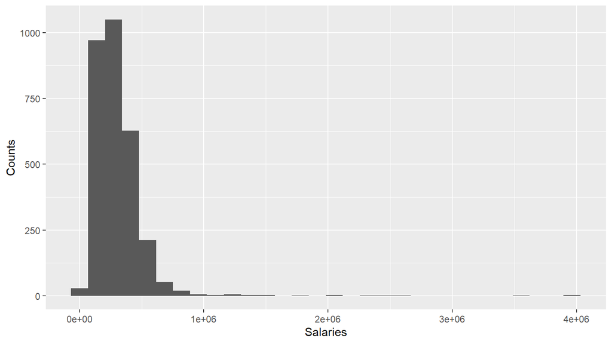

Figure 1. Histogram displaying the distribution of salaries for engineers.

```r
ggplot(data = df, aes(x = salary)) +
    geom_histogram() +
    labs(x = "Salaries", y = "Counts")
```

## Scatterplot

*Visualize the relationship of the outcome variable and the numerical explanatory variable using a scatterplot and comment.* There is a positive correlation between GPAs and salaries for engineering graduates.

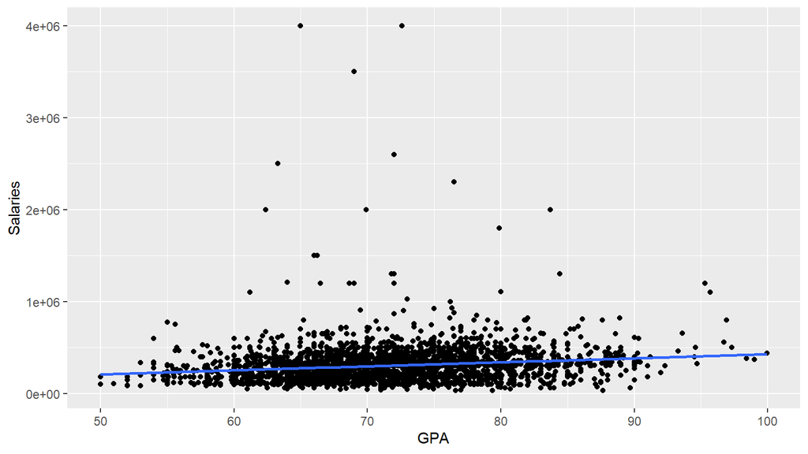

Figure 2. Relationship between college GPA and salary for engineering students

```r
ggplot(data = df, aes(x = gpa, y = salary)) +
    geom_point() +
    labs(x = "GPA", y = "Salaries") +
    geom_smooth(method = "lm", se = FALSE )
```

## Boxplot

*Visualize the relationship of the outcome variable and the categorical explanatory variable using a scatterplot and comment.* Salaries are generally the same throughout the regions; however larger salaries more commonly come out of the northern region.

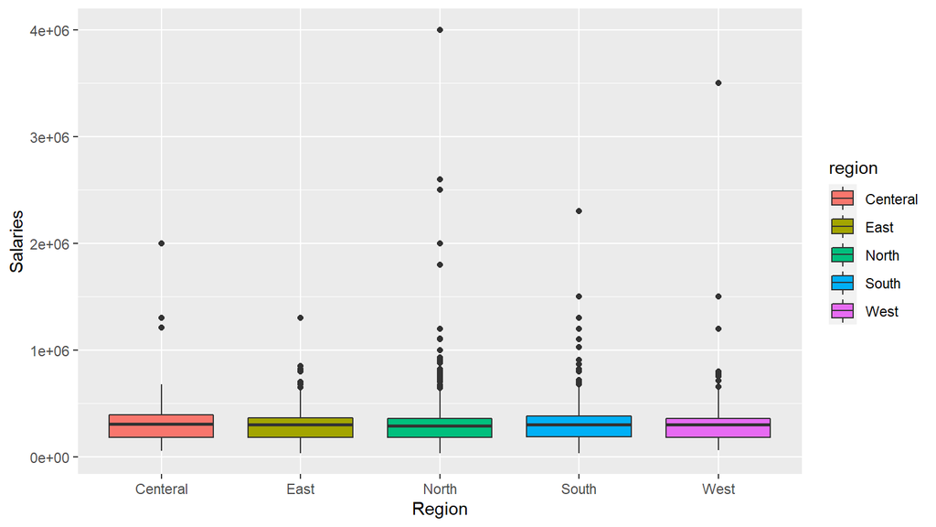

Figure 3. Relationship between region of school attended and salary for engineering students.

```r
ggplot(data = df, aes(x = region, y = salary, fill = region)) +
    geom_boxplot() +
    labs(x = "Region", y = "Salaries")
```

## Region colored scatterplot

*Visualize the relationship of the outcome variable and both explanatory variables using a colored scatterplot and comment.* The salaries in the central region are the least affected by GPA, with a -0.01 correlation, and the eastern region carries the strongest corrolation between GPAs and salaries at a correlation of 0.21.

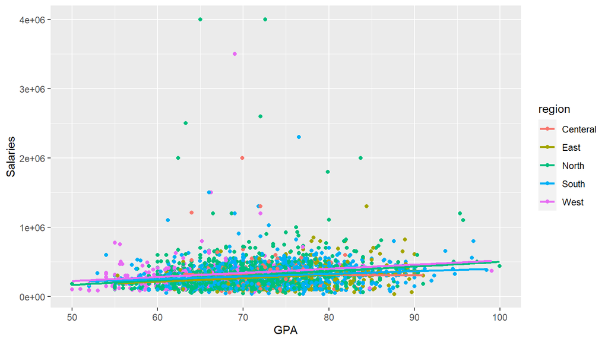

Figure 4. Relationship between salary and GPA coloured by region of the school atteneded for engineering students.

```r
ggplot(data = df, aes(x = gpa, y = salary, color = region)) +
    geom_point() +
    geom_smooth(method = "lm", se = FALSE ) +
    labs(x = "GPA", y = "Salaries")
```

### Gender plots

```r
df %>%
  group_by(gender) %>%
  summarize(n = n(),
            correlation = cor(salary, gpa),
            median_gpa = median(gpa),
            mean_gpa = mean(gpa),
            mean = mean(salary, na.rm = TRUE),
            median = median(salary, na.rm = TRUE),
            sd = sd(salary, na.rm = TRUE))
```

| gender | n | correlation | median_gpa | mean_gpa | mean | median | sd |
| --- | --- | --- | --- | --- | --- | --- | --- |
| f | 715 | 0.1317349 | 74 | 74.05057 | 290139.9 | 3e+05 | 190554.8 |
| m | 2273 | 0.1671125 | 71 | 70.97244 | 309768.6 | 3e+05 | 218626.5 |

As visualized here the correlation between gpas and salaries by gender shows men make a fair amount more than woman on average.

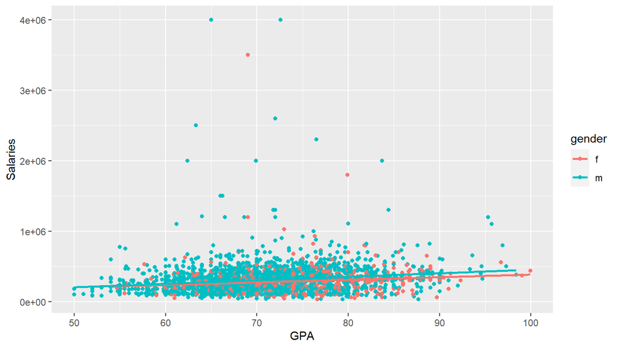

```r
ggplot(data = df, aes(x = gpa, y = salary, color = gender)) +
    geom_point() +
    geom_smooth(method = "lm", se = FALSE ) +
    labs(x = "GPA", y = "Salaries")
```